# Signal and Batch Correction for Mass Spectrometry (sbcms)

Andris Jankevics

Phenome Centre Birmingham, University of Birmingham

a.jankevics@bham.ac.uk

2019-09-02

#### Package

sbcms 1.1.0

# 1 Introduction

# 2 Installation

You should have R version 3.4.1 or above and Rstudio installed to be able to run this notebook.

Execute following commands from the R terminal.

```r
install.packages("devtools")
install.packages("ggplot2")
install.packages("gridExtra")

devtools::install_github("computational-metabolomics/pmp")
devtools::install_github("computational-metabolomics/sbcms")
```

Load the required libraries into the R environment

```r
library(sbcms)
library(ggplot2)
library(reshape2)
library(gridExtra)
library(pmp)
```

# 3 Data set

```r
# DIMS data set is included in 'sbcms' package.
# (MTBLS79) [https://www.ebi.ac.uk/metabolights/MTBLS79]

data <- sbcdata$data
class <- sbcdata$class
batch <- sbcdata$batch
sample_order <- c(1:nrow(data))

# Input data frame or matrix should have features in rows and samples in columns
data <- t(data)

# Input data structure
data[1:5, 1:10]
```

```
#>          batch01_QC01 batch01_QC02 batch01_QC03 batch01_C05 batch01_S07
#> 70.03364     28041.86     28764.55     27063.78    5749.688   17084.280
#> 70.03375     36774.65     37254.92     37692.09    8519.561   21218.940
#> 70.03413     69573.34     70434.15     71633.42   12125.890   40358.150
#> 70.03427     10999.77     12155.28     11627.33    1420.484    6183.730
#> 73.0584      15580.51     14720.44     16391.32    9939.475    7765.855
#>          batch01_C10 batch01_QC04 batch01_S01 batch01_C03 batch01_S05
#> 70.03364    48806.23     30500.00   13219.170    32055.28    18401.48
#> 70.03375    56400.47     40890.81   16790.770    37597.86    24059.84
#> 70.03413   121724.00     79970.91   30546.890    76636.70    45181.97
#> 70.03427    19463.35     14631.68    5035.649    12350.38     5776.31
#> 73.0584     25097.38     17513.41    8071.987    17673.67     8355.78
```

```r
class[1:10]
```

```
#>  [1] "QC" "QC" "QC" "C"  "S"  "C"  "QC" "S"  "C"  "S"
```

```r
batch[1:10]
```

```
#>  [1] 1 1 1 1 1 1 1 1 1 1
```

```r
sample_order[1:10]
```

```
#>  [1]  1  2  3  4  5  6  7  8  9 10
```

# 4 Applying signal and batch correction

Function QCRSC should be used to apply signal batch correction. Input peak table should be in format where features are in rows and samples in columns.

Argument ‘order’ should be numeric vector containing sample injection order during analytical measurement and should be the same length as number of columns in peak table.

Argument `batch’ should be numeric vector containing values of sample batch number. If all samples were measured in 1 batch, then all values in the ‘batch’ vector should be ‘1’.

Values for ‘classes’ should be character vector containing sample class labels. Class label for quality control sample has to be “QC”.

```r
corrected_data <- sbcms::QCRSC(df=data, order=sample_order, batch=batch,
    classes=class, spar=0, minQC=4)
```

```
#> The number of NA and <= 0 values in peaksData before QC-RSC: 9222
```

# 5 Visualising results

Function ‘sbcmsPlot’ is providing visual comparison of data before and after correction. Fore example we can check output for features ‘1’, ‘5’, and ‘30’ in peak matrix.

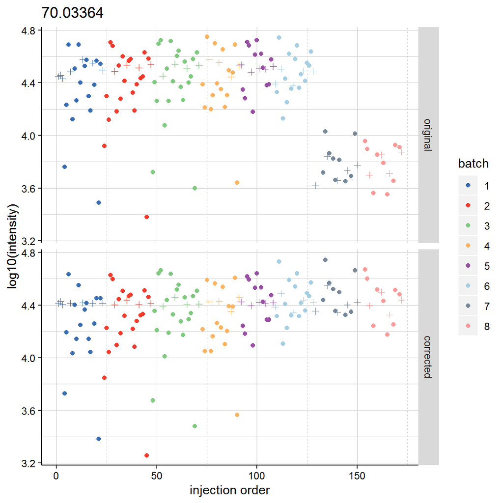

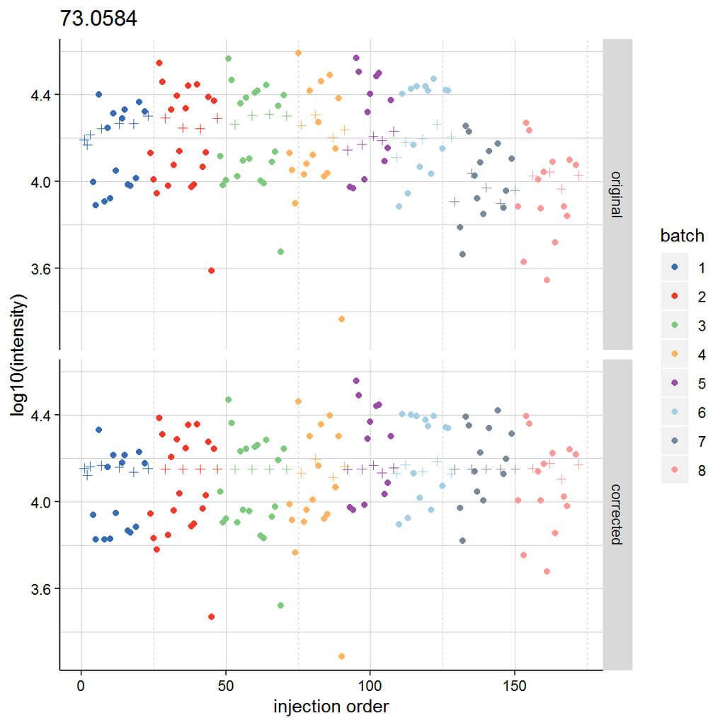

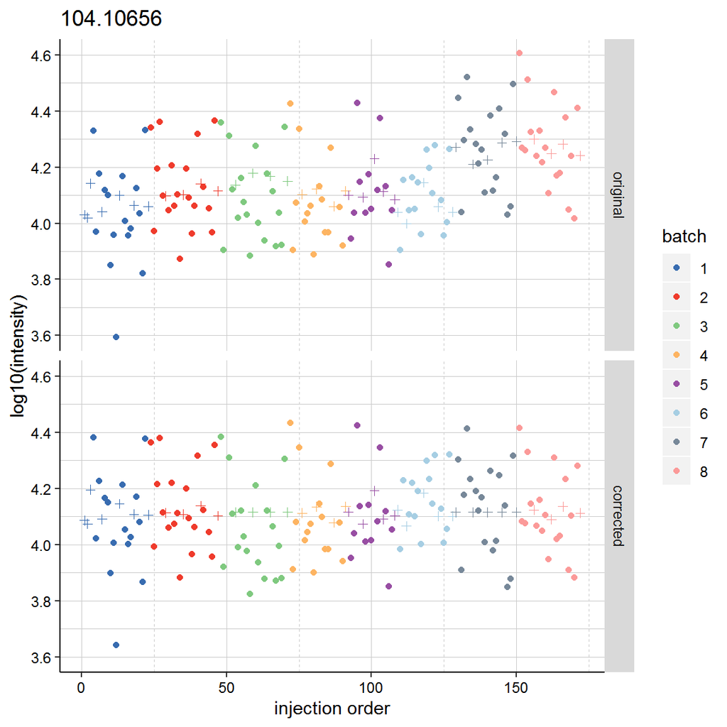

```r
plots <- sbcmsPlot (df=data, corrected_df=corrected_data, classes=class,
    batch=batch, output=NULL, indexes=c(1, 5, 30))
plots
```

The scores plots of principal components analysis (PCA) before and after correction can be used to asses effects of data correction.

In this example, PQN method used to normalise data, KNN used for missing value imputation and glog for data scaling.

A more detailed overview on data pre-processing is detailed in Di Guida et al. (2016).

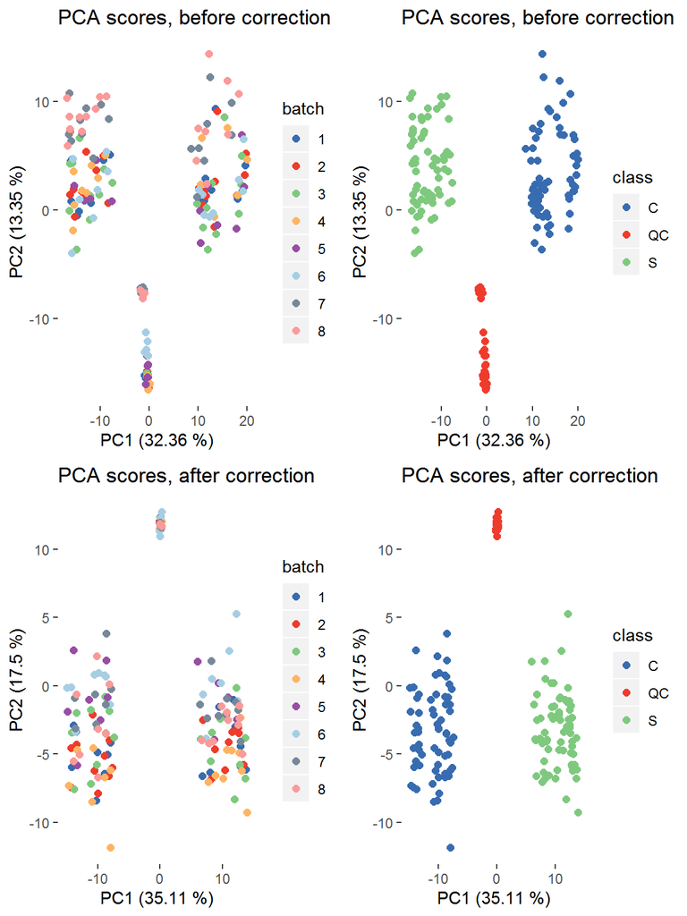

```r
manual_color = c("#386cb0", "#ef3b2c", "#7fc97f", "#fdb462", "#984ea3",
    "#a6cee3", "#778899", "#fb9a99", "#ffff33")

pca_data <- pmp::pqn_normalisation(data, classes=class, qc_label="QC")[[1]]
pca_data <- pmp::mv_imputation(pca_data, method="KNN", k=5, rowmax=0.5,
    colmax=0.5, maxp=NULL, check_df=FALSE)
pca_data <- pmp::glog_transformation(pca_data, classes=class, qc_label="QC")

pca_corrected_data <- pmp::pqn_normalisation(corrected_data, classes=class,
    qc_label="QC")[[1]]
pca_corrected_data <- pmp::mv_imputation(pca_corrected_data, method="KNN", k=5,
    rowmax=0.5, colmax=0.5, maxp=NULL, check_df=FALSE)
pca_corrected_data <- pmp::glog_transformation(pca_corrected_data,
    classes=class, qc_label="QC")

pca_data <- prcomp(t(pca_data), center=TRUE, scale=FALSE)
pca_corrected_data <- prcomp(t(pca_corrected_data), center=TRUE, scale=FALSE)

# Calculate percentage of explained variance of the first two PC's
exp_var_pca <- round(((pca_data$sdev^2)/sum(pca_data$sdev^2)*100)[1:2],2)
exp_var_pca_corrected <- round(((pca_corrected_data$sdev^2) /
    sum(pca_corrected_data$sdev^2)*100)[1:2],2)

plots <- list()

plotdata <- data.frame(PC1=pca_data$x[, 1], PC2=pca_data$x[, 2],
    batch=as.factor(batch), class=class)

plots[[1]] <- ggplot(data=plotdata, aes(x=PC1, y=PC2, col=batch)) +
    geom_point(size=2) + theme(panel.background=element_blank()) +
    scale_color_manual(values=manual_color) +
    ggtitle("PCA scores, before correction") +
    xlab(paste0("PC1 (", exp_var_pca[1] ," %)")) +
    ylab(paste0("PC2 (", exp_var_pca[2] ," %)"))

plots[[2]] <- ggplot(data=plotdata, aes(x=PC1, y=PC2, col=class)) +
    geom_point(size=2) + theme(panel.background=element_blank()) +
    scale_color_manual(values=manual_color) +
    ggtitle("PCA scores, before correction") +
    xlab(paste0("PC1 (", exp_var_pca[1] ," %)")) +
    ylab(paste0("PC2 (", exp_var_pca[2] ," %)"))

plotdata_corr <- data.frame(PC1=pca_corrected_data$x[, 1],
    PC2=pca_corrected_data$x[, 2], batch=as.factor(batch), class=class)

plots[[3]] <- ggplot(data=plotdata_corr, aes(x=PC1, y=PC2, col=batch)) +
    geom_point(size=2) +
    theme(panel.background=element_blank()) +
    scale_color_manual(values=manual_color) +
    ggtitle("PCA scores, after correction") +
    xlab(paste0("PC1 (", exp_var_pca_corrected[1] ," %)")) +
    ylab(paste0("PC2 (", exp_var_pca_corrected[2] ," %)"))

plots[[4]] <- ggplot(data=plotdata_corr, aes(x=PC1, y=PC2, col=class)) +
    geom_point(size=2) +
    theme(panel.background=element_blank()) +
    scale_color_manual(values=manual_color) +
    ggtitle("PCA scores, after correction") +
    xlab(paste0("PC1 (", exp_var_pca_corrected[1] ," %)")) +
    ylab(paste0("PC2 (", exp_var_pca_corrected[2] ," %)"))

grid.arrange(ncol=2, plots[[1]], plots[[2]], plots[[3]], plots[[4]])
```

# References

Di Guida, Riccardo, Jasper Engel, J William Allwood, Ralf JM Weber, Martin R Jones, Ulf Sommer, Mark R Viant, and Warwick B Dunn. 2016. “Non-Targeted Uhplc-Ms Metabolomic Data Processing Methods: A Comparative Investigation of Normalisation, Missing Value Imputation, Transformation and Scaling.” *Metabolomics* 12 (5): 93.

Kirwan, Jennifer A, Ralf JM Weber, David I Broadhurst, and Mark R Viant. 2014. “Direct Infusion Mass Spectrometry Metabolomics Dataset: A Benchmark for Data Processing and Quality Control.” *Scientific Data* 1: 140012.